# Výtvarná tvorba (júlový turnus)

Zpět na rozcestník zpětné vazby | Tento report we Wordu | Data v CSV

## Hodnocení kurzu

Průměrná známka:

| Blok setkání | Průměrná známka |
| --- | --- |
| A | 1.17 |
| B | 1.21 |
| oba | 1.18 |

### Hodnocení po dnech

A a B jsou bloky (A je 9-10:30, B je 11-12:30)

Známky jsou jako ve škole: 1 je nejlepší, 5 nejhorší

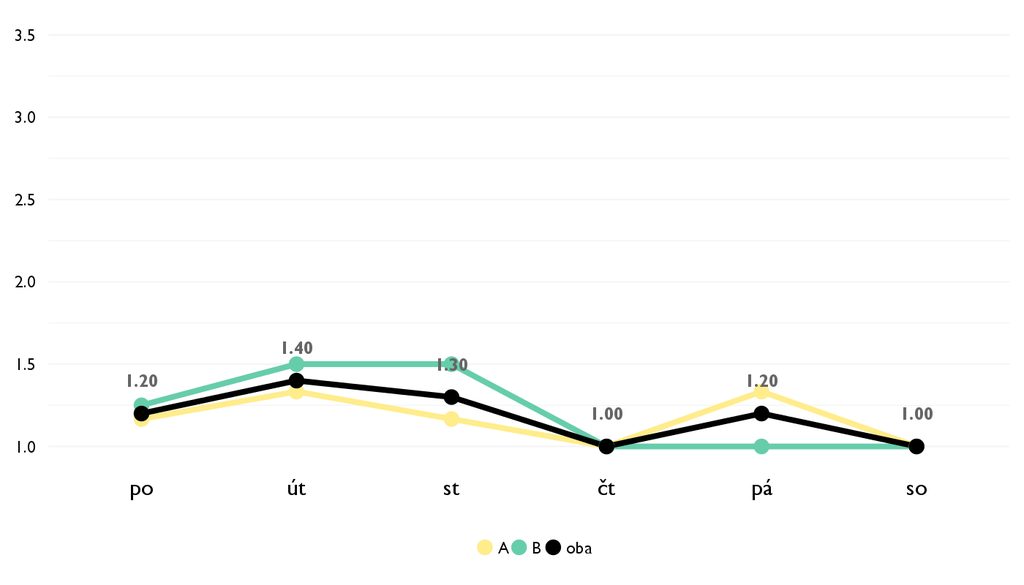

### Co se na kurzu líbilo

- Pacilo sa mi ze sme brali nielen teoriu ale tvorili sme aj sami, usporiadali sme vernisaz a ze Janka sa o nas strarala takj ako s astarala. Rozhovory o umeni s nou ma vyrazne posuvali dopredu
- Priestor pre sebavyjadrenie, oboznámenie s roznymi technikami , inšpirácia.
- Pohlad na cast vytvarky ktorej sa aktivne nevenujem, teoria, popis obrazov
- Celková voľnosť kurzu.
- Kreativita to ako sme tvorili a zároveň učili nove vec
- To ze sme sa aj naucili nieco z dejin umenia a taktiez sme stihli nieco vytvorit. Zlomil vo mne moj strach/truc z kreslenia, co hodnotim ako osobne obrovske plus. Velmi velmi sa mi pacil a keby som mohla urcite si ho este mnohokrat zopakujem.
- To, ze sme sa rozpravali aj o dejinach umenia a, ze sme mali primeranu volnost v tvoreni.
- Líbilo se mi, že jsme měli hodněkráte volnou ruku v tom, jaké techniky použítl. Skvělá byla i témata, která jsme zpracovávali, ať už šlo o moderní umění nebo o středověký komiks.
- spojenie teórie a praxe
- Lektorka nám dávala v tvorbe “voľnú ruku” a páčila sa mi interpretácia umeleckých diel.

### Co na kurzu změnit

- Je skvely taky aky je
- Aby naň bolo viac času. :)
- Urcite viac casu.
- Zaviedla by som možno trochu viac teórie.
- Viac času na tvorbu
- Mozno by obcas bolo treba viac casu najma na kreslenie ale neviem, ze ako sa to da dostiahnut… Plus co ma moc neoslovilo v naplni kurzu bol landart.
- asi nic.
- nic.
- možno viac teoretických poznatkov
- Viac výtvarných potrieb( farby, stojany… .

## Hodnocení lektora

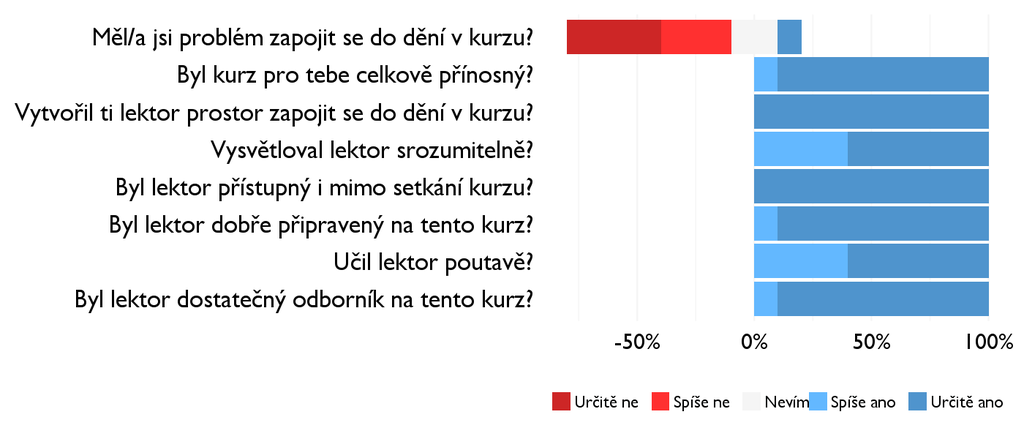

### Komentáře k lektorovi

- lektor by měl rozhodně pokračovat v tom, co dělá a jak!

## Náročnost kurzu

### **Jak hodnotíš náročnost…**

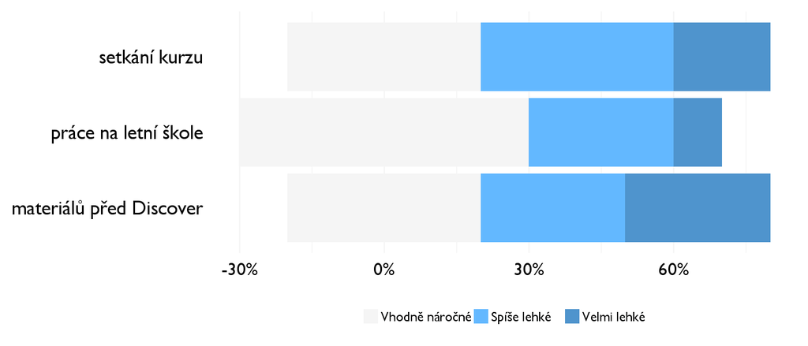

## Didaktika

Na některé otázky jsme se na augustovém turnuse neptali - tam uvidíte nadpis bez grafu.

### Jak lektor učí a měl by to změnit?

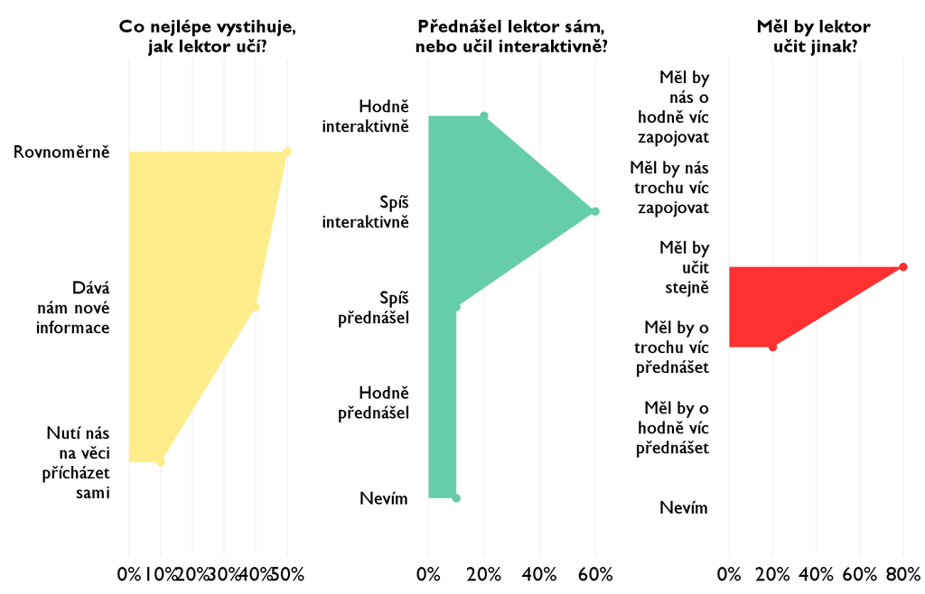

### Jak se studentům nejlépe učí?

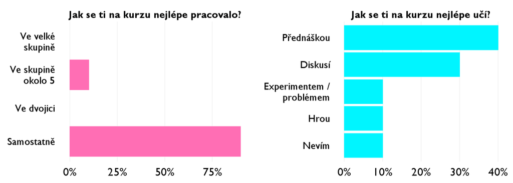

## Ovlivnil tě kurz nějak?

**Pokud ano, jak? Pokud ne, proč ne?**

- Vdaka tomuto kurzu som objavila Kupku
- Podám si prihlášku an dizajn a po novom mám pozitívny názor na moderné umenie.
- Inak posudit obrazy
- Uvedomila som si , že výtvarná tvrorba nie je smer , ktorý by som chcela študovať.
- Ano, prebudil vo mne chuť tvoriť
- Ano, dal mi opat chut kreslit a dozvedat sa viac o teorii a dejinach umenia.
- Uistil ma, ze vo svojom zivote urcite chcem ist umeleckym smerom.
- Začnu znovu tvořit i přesto, že nemám nějaké vyšší ambice.
- v tom ako sa dívam na moderné umenie
- Kurz ma ovplyvnil k chápaniu umenia